# Assignment 1: Bike Sharing

Khoi Mai Tieu

# Introduction

For this assignment, I chose the [Bike Sharing dataset](https://archive.ics.uci.edu/dataset/275/bike+sharing+dataset), which provides a comprehensive log of bike-sharing rentals collected from the Capital Bikeshare system in Washington D.C. over two years, 2011 and 2012. The rental data is combined with environmental and seasonal factors that influence bike usage. Variables like temperature, humidity, wind speed, weather conditions, and whether the day is a holiday or weekend are provided.

```r
# Download the dataset
download.file('https://archive.ics.uci.edu/static/public/275/bike+sharing+dataset.zip','bike-sharing.zip')
unzip('bike-sharing.zip', files = 'day.csv')

# Load the dataset
df <- read.csv('day.csv', header = TRUE)

# Remove zip and csv files
file.remove(list.files(pattern = "\\.zip$|\\.csv$"))
```

The dataset contains 16 columns and 731 obs. Below are a brief overview of the columns

| Variable | Role | Type | Description |
| --- | --- | --- | --- |
| instant | Feature | Integer | Record index |
| dteday | Feature | Date | Date of the record |
| season | Feature | Categorical | Season (1 = Spring, 2 = Summer, 3 = Fall, 4 = Winter) |
| yr | Feature | Categorical | Year (0 = 2011, 1 = 2012) |
| mnth | Feature | Categorical | Month (1 to 12) |
| holiday | Feature | Categorical | Whether the day is a holiday (1 = Yes, 0 = No) |
| weekday | Feature | Categorical | Day of the week (0 = Sunday, 1 = Monday, …, 6 = Saturday) |
| workingday | Feature | Categorical | Whether the day is a working day (1 = Yes, 0 = No) |
| weathersit | Feature | Categorical | Weather situation (1 = Clear, 2 = Mist, 3 = Light Snow/Rain, 4 = Heavy Rain/Snow) |
| temp | Feature | Continuous | Normalized temperature in Celsius (values divided by 41) |
| atemp | Feature | Continuous | Normalized feeling temperature in Celsius (values divided by 50) |
| hum | Feature | Continuous | Normalized humidity (values divided by 100) |
| windspeed | Feature | Continuous | Normalized wind speed (values divided by 67) |
| casual | Other | Integer | Count of casual (unregistered) users |
| registered | Other | Integer | Count of registered users |
| cnt | Target | Integer | Total count of bike rentals, including both casual and registered users |

This dataset is suitable for both classification and regression tasks. Key questions it can help address include:

- How can bike-sharing systems be optimized by identifying peak usage periods?
- How can planners prepare for special events or holidays?
- How does the weather impact bike rentals?

# Problem 1. Summary Statistics Table

```r
st(df)
```

Summary Statistics

| Variable | N | Mean | Std. Dev. | Min | Pctl. 25 | Pctl. 75 | Max |
| --- | --- | --- | --- | --- | --- | --- | --- |
| instant | 731 | 366 | 211 | 1 | 184 | 548 | 731 |
| season | 731 | 2.5 | 1.1 | 1 | 2 | 3 | 4 |
| yr | 731 | 0.5 | 0.5 | 0 | 0 | 1 | 1 |
| mnth | 731 | 6.5 | 3.5 | 1 | 4 | 10 | 12 |
| holiday | 731 | 0.029 | 0.17 | 0 | 0 | 0 | 1 |
| weekday | 731 | 3 | 2 | 0 | 1 | 5 | 6 |
| workingday | 731 | 0.68 | 0.47 | 0 | 0 | 1 | 1 |
| weathersit | 731 | 1.4 | 0.54 | 1 | 1 | 2 | 3 |
| temp | 731 | 0.5 | 0.18 | 0.059 | 0.34 | 0.66 | 0.86 |
| atemp | 731 | 0.47 | 0.16 | 0.079 | 0.34 | 0.61 | 0.84 |
| hum | 731 | 0.63 | 0.14 | 0 | 0.52 | 0.73 | 0.97 |
| windspeed | 731 | 0.19 | 0.077 | 0.022 | 0.13 | 0.23 | 0.51 |
| casual | 731 | 848 | 687 | 2 | 316 | 1096 | 3410 |
| registered | 731 | 3656 | 1560 | 20 | 2497 | 4776 | 6946 |
| cnt | 731 | 4504 | 1937 | 22 | 3152 | 5956 | 8714 |

Refer the result in **Table 2: Summary Statistics**

# Problem 2. Bad Data Visualization

## 2.1. Categorical Variable (season)

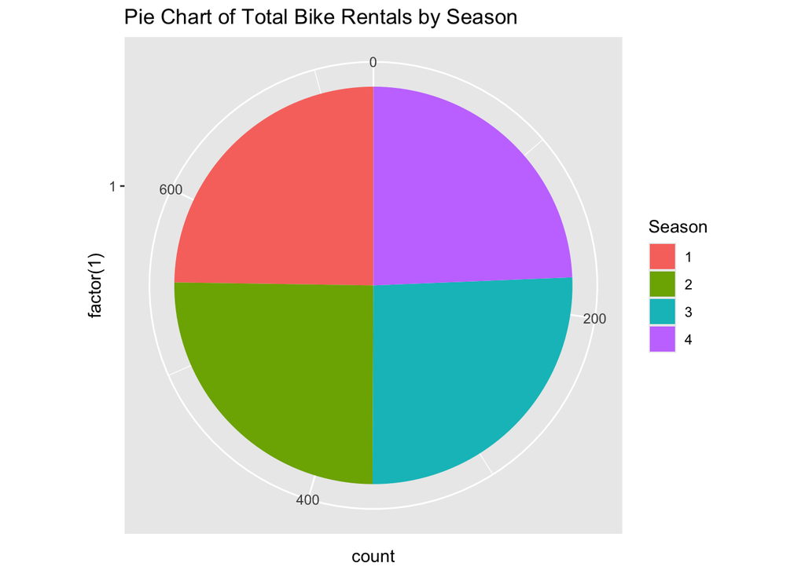

```r
ggplot(df, aes(x = factor(1), fill = factor(season))) +
  geom_bar(width = 1) +
  coord_polar(theta = "y") +
  labs(title = "Pie Chart of Total Bike Rentals by Season", fill = "Season")
```

## 2.2. Continuous Variable (temp)

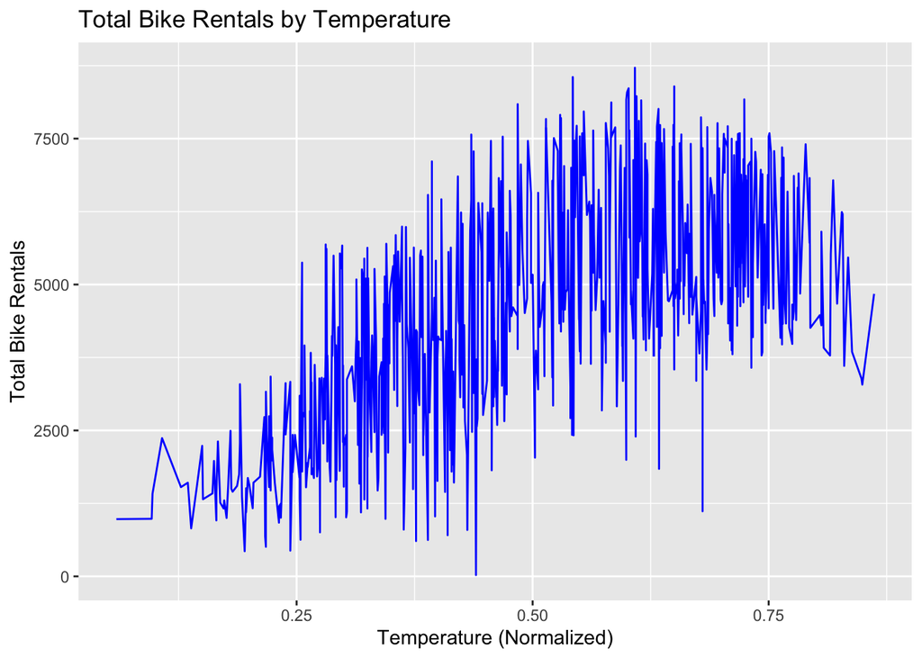

```r
ggplot(df, aes(x = temp, y = cnt)) +
  geom_line(color = "blue") +
  labs(title = "Total Bike Rentals by Temperature",
       x = "Temperature (Normalized)",
       y = "Total Bike Rentals")
```

In above example - line chart of Total Bike Rentals by Temperature - giving the false impression of a sequential or time-based relationship and it can not show a clear trend, so this visualization offers little meaningful insight into how bike rentals respond to temperature changes.

# Problem 3. Good Data Visualization

## 3.1. Categorical Variable

For the chart shown in section 2.1, bar charts are much better for comparing categorical variables like seasons, as they show the total bike rentals for each season clearly. And we can compare the height of the bars to see which season has the highest bike rentals. In addition, the y-axis starts at zero, providing an accurate sense of scale and preventing any distortion.

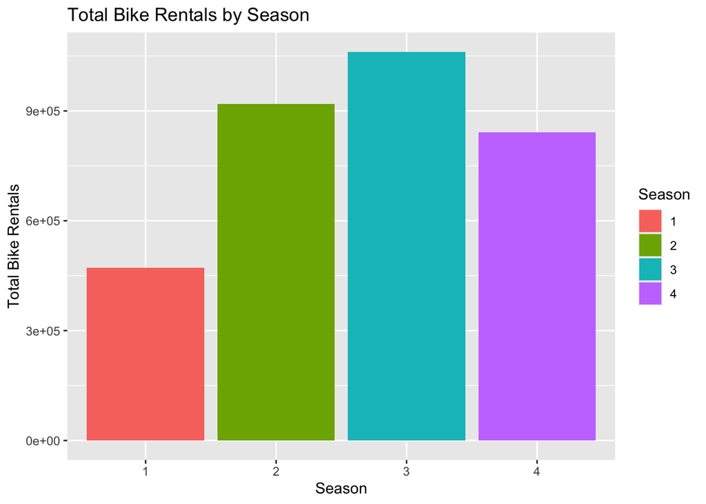

```r
ggplot(df, aes(x = factor(season), y = cnt, fill = factor(season))) +
  geom_bar(stat = "summary", fun = "sum") +
  labs(title = "Total Bike Rentals by Season",
       x = "Season",
       y = "Total Bike Rentals",
       fill = "Season")
```

## 3.2. Continuous Variable

The scatter plot is better suited for continuous data like temperature and rentals. It shows the spread and density of the data points without implying a sequential connection. On the other hand, adding a smoothing line (LOESS) or trend line gives a clear indication of the relationship between temperature and total bike rentals, helping to highlight any trends in the data.

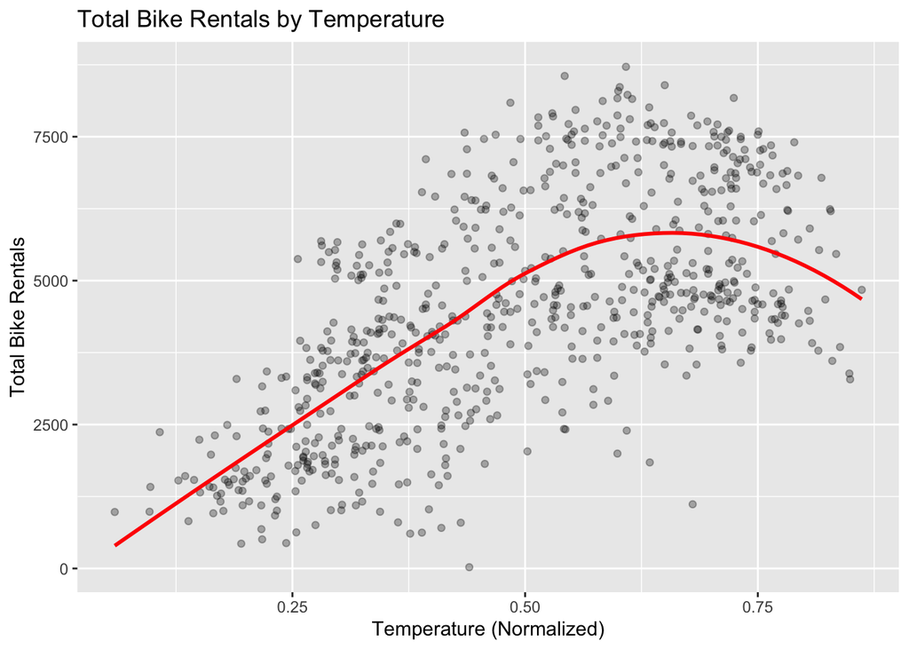

```r
ggplot(data = df, aes(x = temp, y = cnt)) +
  geom_point(alpha = 0.3) +
  geom_smooth(formula = y ~ x, method = "loess", color = "red", se = FALSE) +
  labs(title = "Total Bike Rentals by Temperature",
       x = "Temperature (Normalized)",
       y = "Total Bike Rentals")
```

# Problem 4. Simple analysis

```r
y <- df$cnt
X <- df[, c('season', 'mnth', 'holiday', 'weekday', 'workingday',
              'weathersit', 'temp', 'atemp', 'hum', 'windspeed')]
```

```r
cor(X)
```

```
##                  season         mnth      holiday       weekday   workingday
## season      1.000000000  0.831440114 -0.010536659 -0.0030798813  0.012484963
## mnth        0.831440114  1.000000000  0.019190895  0.0095093129 -0.005900951
## holiday    -0.010536659  0.019190895  1.000000000 -0.1019602689 -0.253022700
## weekday    -0.003079881  0.009509313 -0.101960269  1.0000000000  0.035789674
## workingday  0.012484963 -0.005900951 -0.253022700  0.0357896736  1.000000000
## weathersit  0.019211028  0.043528098 -0.034626841  0.0310874694  0.061200430
## temp        0.334314856  0.220205335 -0.028555535 -0.0001699624  0.052659810
## atemp       0.342875613  0.227458630 -0.032506692 -0.0075371318  0.052182275
## hum         0.205444765  0.222203691 -0.015937479 -0.0522321004  0.024327046
## windspeed  -0.229046337 -0.207501752  0.006291507  0.0142821241 -0.018796487
##             weathersit          temp        atemp         hum    windspeed
## season      0.01921103  0.3343148564  0.342875613  0.20544476 -0.229046337
## mnth        0.04352810  0.2202053352  0.227458630  0.22220369 -0.207501752
## holiday    -0.03462684 -0.0285555350 -0.032506692 -0.01593748  0.006291507
## weekday     0.03108747 -0.0001699624 -0.007537132 -0.05223210  0.014282124
## workingday  0.06120043  0.0526598102  0.052182275  0.02432705 -0.018796487
## weathersit  1.00000000 -0.1206022365 -0.121583354  0.59104460  0.039511059
## temp       -0.12060224  1.0000000000  0.991701553  0.12696294 -0.157944120
## atemp      -0.12158335  0.9917015532  1.000000000  0.13998806 -0.183642967
## hum         0.59104460  0.1269629390  0.139988060  1.00000000 -0.248489099
## windspeed   0.03951106 -0.1579441204 -0.183642967 -0.24848910  1.000000000
```

## 4.1. Linear regression model with all available variables

```r
full.model <- lm(y ~ ., data = X)
summary(full.model)
```

```
##
## Call:
## lm(formula = y ~ ., data = X)
##
## Residuals:
##     Min      1Q  Median      3Q     Max
## -4278.2  -973.0  -190.1  1056.6  4006.7
##
## Coefficients:
##             Estimate Std. Error t value Pr(>|t|)
## (Intercept)  3033.31     360.95   8.404 2.30e-16 ***
## season        482.12      84.11   5.732 1.46e-08 ***
## mnth          -29.27      26.23  -1.116   0.2649
## holiday      -479.95     308.83  -1.554   0.1206
## weekday        61.35      25.04   2.450   0.0145 *
## workingday    112.39     110.62   1.016   0.3099
## weathersit   -494.64     120.24  -4.114 4.35e-05 ***
## temp         2381.14    2156.21   1.104   0.2698
## atemp        3634.09    2441.58   1.488   0.1371
## hum         -2234.15     478.65  -4.668 3.63e-06 ***
## windspeed   -3145.35     700.33  -4.491 8.25e-06 ***
## ---
## Signif. codes:  0 '***' 0.001 '**' 0.01 '*' 0.05 '.' 0.1 ' ' 1
##
## Residual standard error: 1340 on 720 degrees of freedom
## Multiple R-squared:  0.528,  Adjusted R-squared:  0.5214
## F-statistic: 80.53 on 10 and 720 DF,  p-value: < 2.2e-16
```

We see that multiple R-squared was 0.528. This indicates that around 52.8% of the variance in bike rentals is explained by the selected independent variables. However, the Adjusted R-squared is slightly lower at 0.5214, suggesting that some non-significant variables might have been included, which slightly reduces the explanatory power of the model.

## 4.2. Model Selection Process

Initial full and null model

```r
library(MASS)

full.model <- lm(y ~ ., data = as.data.frame(X))
null.model <- lm(y ~ 1, data = as.data.frame(X))
```

### 4.2.1. Backward Elimination

- Starting with the full model
- Removing non-significant variables step by step

```r
model.backward.aic <- stepAIC(object = full.model, scope = null.model, direction = 'backward')
```

```r
summary(model.backward.aic)
```

```
##
## Call:
## lm(formula = y ~ season + holiday + weekday + weathersit + atemp +
##     hum + windspeed, data = as.data.frame(X))
##
## Residuals:
##     Min      1Q  Median      3Q     Max
## -4393.3  -957.0  -183.5  1074.3  3885.6
##
## Coefficients:
##             Estimate Std. Error t value Pr(>|t|)
## (Intercept)  3008.14     341.53   8.808  < 2e-16 ***
## season        404.91      48.79   8.298 5.16e-16 ***
## holiday      -562.77     298.79  -1.884   0.0600 .
## weekday        62.03      24.99   2.482   0.0133 *
## weathersit   -477.28     119.88  -3.981 7.55e-05 ***
## atemp        6369.91     334.62  19.036  < 2e-16 ***
## hum         -2332.37     475.52  -4.905 1.16e-06 ***
## windspeed   -3021.61     690.98  -4.373 1.41e-05 ***
## ---
## Signif. codes:  0 '***' 0.001 '**' 0.01 '*' 0.05 '.' 0.1 ' ' 1
##
## Residual standard error: 1341 on 723 degrees of freedom
## Multiple R-squared:  0.5256, Adjusted R-squared:  0.521
## F-statistic: 114.4 on 7 and 723 DF,  p-value: < 2.2e-16
```

### 4.2.2. Forward Selection

- Starting with the null model (only intercept)
- Adding variables based on significance

```r
model.forward.aic <- stepAIC(object = null.model, scope = full.model$terms, direction = 'forward')
```

```r
summary(model.forward.aic)
```

```
##
## Call:
## lm(formula = y ~ atemp + weathersit + season + hum + windspeed +
##     weekday + holiday, data = as.data.frame(X))
##
## Residuals:
##     Min      1Q  Median      3Q     Max
## -4393.3  -957.0  -183.5  1074.3  3885.6
##
## Coefficients:
##             Estimate Std. Error t value Pr(>|t|)
## (Intercept)  3008.14     341.53   8.808  < 2e-16 ***
## atemp        6369.91     334.62  19.036  < 2e-16 ***
## weathersit   -477.28     119.88  -3.981 7.55e-05 ***
## season        404.91      48.79   8.298 5.16e-16 ***
## hum         -2332.37     475.52  -4.905 1.16e-06 ***
## windspeed   -3021.61     690.98  -4.373 1.41e-05 ***
## weekday        62.03      24.99   2.482   0.0133 *
## holiday      -562.77     298.79  -1.884   0.0600 .
## ---
## Signif. codes:  0 '***' 0.001 '**' 0.01 '*' 0.05 '.' 0.1 ' ' 1
##
## Residual standard error: 1341 on 723 degrees of freedom
## Multiple R-squared:  0.5256, Adjusted R-squared:  0.521
## F-statistic: 114.4 on 7 and 723 DF,  p-value: < 2.2e-16
```

### 4.2.3. Stepwise Selection

```r
model.stepwise.aic <- stepAIC(object = null.model, scope = full.model$terms, direction = 'both')
```

```r
summary(model.stepwise.aic)
```

```
##
## Call:
## lm(formula = y ~ atemp + weathersit + season + hum + windspeed +
##     weekday + holiday, data = as.data.frame(X))
##
## Residuals:
##     Min      1Q  Median      3Q     Max
## -4393.3  -957.0  -183.5  1074.3  3885.6
##
## Coefficients:
##             Estimate Std. Error t value Pr(>|t|)
## (Intercept)  3008.14     341.53   8.808  < 2e-16 ***
## atemp        6369.91     334.62  19.036  < 2e-16 ***
## weathersit   -477.28     119.88  -3.981 7.55e-05 ***
## season        404.91      48.79   8.298 5.16e-16 ***
## hum         -2332.37     475.52  -4.905 1.16e-06 ***
## windspeed   -3021.61     690.98  -4.373 1.41e-05 ***
## weekday        62.03      24.99   2.482   0.0133 *
## holiday      -562.77     298.79  -1.884   0.0600 .
## ---
## Signif. codes:  0 '***' 0.001 '**' 0.01 '*' 0.05 '.' 0.1 ' ' 1
##
## Residual standard error: 1341 on 723 degrees of freedom
## Multiple R-squared:  0.5256, Adjusted R-squared:  0.521
## F-statistic: 114.4 on 7 and 723 DF,  p-value: < 2.2e-16
```

### 4.2.4. Best Subset Model

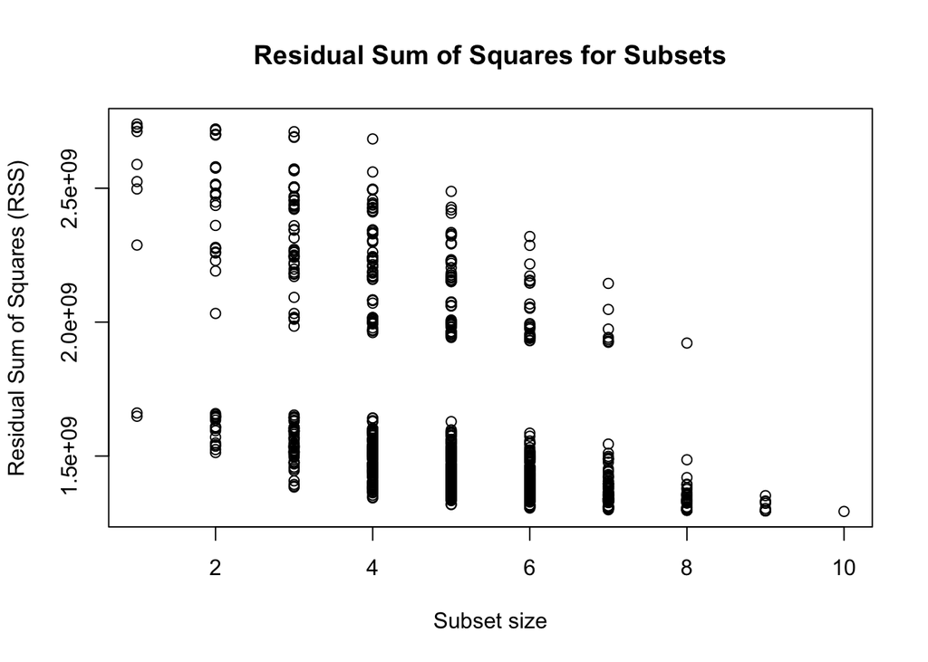

```r
num_vars <- ncol(X)

allCombinations <- sapply(1:num_vars, function(m) combn(x = 1:num_vars, m = m))

null.model <- lm(y ~ 1)
result.AIC <- extractAIC(null.model)
result.RSS <- cbind(1, deviance(null.model))

for (i in 1:num_vars) {
  for (j in 1:ncol(allCombinations[[i]])) {
    model <- lm(y ~ ., data = as.data.frame(X[, allCombinations[[i]][, j]]))
    result.AIC <- rbind(result.AIC, extractAIC(model))
    result.RSS <- rbind(result.RSS, cbind(length(allCombinations[[i]][, j]), deviance(model)))
  }
}

# Plot RSS for all subset sizes
plot(result.RSS[, 1], result.RSS[, 2], main = 'Residual Sum of Squares for Subsets',
     xlab = 'Subset size', ylab = 'Residual Sum of Squares (RSS)')
```

```r
# identify the model with the smallest RSS
best.RSS <- result.RSS[which.min(result.RSS[, 2]), ]
index <- which.min(result.RSS[result.RSS[, 1] == best.RSS[1], 2])
variables.best.model <- allCombinations[[best.RSS[1]]][, index]

# final model
model.bestSubset.RSS <- lm(y ~ ., data = as.data.frame(X[, variables.best.model]))
summary(model.bestSubset.RSS)
```

```
##
## Call:
## lm(formula = y ~ ., data = as.data.frame(X[, variables.best.model]))
##
## Residuals:
##     Min      1Q  Median      3Q     Max
## -4278.2  -973.0  -190.1  1056.6  4006.7
##
## Coefficients:
##             Estimate Std. Error t value Pr(>|t|)
## (Intercept)  3033.31     360.95   8.404 2.30e-16 ***
## season        482.12      84.11   5.732 1.46e-08 ***
## mnth          -29.27      26.23  -1.116   0.2649
## holiday      -479.95     308.83  -1.554   0.1206
## weekday        61.35      25.04   2.450   0.0145 *
## workingday    112.39     110.62   1.016   0.3099
## weathersit   -494.64     120.24  -4.114 4.35e-05 ***
## temp         2381.14    2156.21   1.104   0.2698
## atemp        3634.09    2441.58   1.488   0.1371
## hum         -2234.15     478.65  -4.668 3.63e-06 ***
## windspeed   -3145.35     700.33  -4.491 8.25e-06 ***
## ---
## Signif. codes:  0 '***' 0.001 '**' 0.01 '*' 0.05 '.' 0.1 ' ' 1
##
## Residual standard error: 1340 on 720 degrees of freedom
## Multiple R-squared:  0.528,  Adjusted R-squared:  0.5214
## F-statistic: 80.53 on 10 and 720 DF,  p-value: < 2.2e-16
```

- Through Backward Elimination, Forward Selection, and Stepwise Selection, significant variables were selected such as season, atemp, weathersit, hum, and windspeed, which were consistently found to be important.
- However, there are variables like mnth, holiday, and workingday that were less significant and had high p-values, indicating that they might not strongly affect the number of rentals.

## 4.3. Model Performance Comparison

```r
full.model <- lm(y ~ ., data = as.data.frame(X))
null.model <- lm(y ~ 1, data = as.data.frame(X))

# Forward Selection
scp <- full.model$terms

rss1 <- vector("numeric", num_vars)
for (j in 1:num_vars) {
  mdl <- stepAIC(object = null.model, scope = scp, direction =
                   'forward', k = 0, steps = j)
  rss1[j] <- sum((mdl$fitted.values-y)^2)
}

# Backward Elimination
rss2 <- vector("numeric", num_vars)
for (j in 1:num_vars) {
  mdl <- stepAIC(object = full.model, scope = list(lower = null.model, upper = full.model),
                 direction = 'backward', k = 1e6, steps = j-1)
  rss2[j] <- sum((mdl$fitted.values - y)^2)
}
rss2 <- rev(rss2)

# Best Subset Selection
rss3 <- vector("numeric", num_vars)
for (j in 1:num_vars) {
  rss3[j] <- min(result.RSS[result.RSS[, 1] == j, 2])
}
```

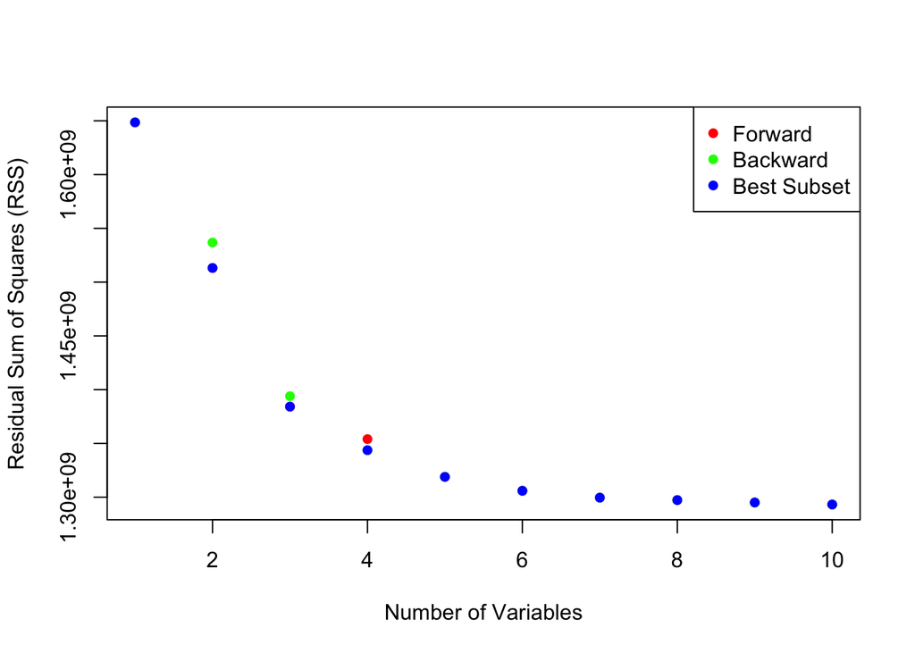

```r
plot(0, 0, xlim = c(1, num_vars), ylim = c(min(rss1, rss2, rss3), max(rss1, rss2, rss3)),
     type = "n", xlab = "Number of Variables", ylab = "Residual Sum of Squares (RSS)")
lines(1:num_vars, rss1, col = "red", type = 'p', pch = 16, lty = 1)  # Forward
lines(1:num_vars, rss2, col = "green", type = 'p', pch = 16, lty = 2)  # Backward
lines(1:num_vars, rss3, col = "blue", type = 'p', pch = 16, lty = 3)  #Should be the minimum given that we are exploring all possible combinations
legend("topright", legend = c("Forward", "Backward", "Best Subset"), col = c("red", "green", "blue"), pch = 16)
```